# Praktikum 5 Anreg

# Library

```r
library(readxl)    # untuk membaca data
library(GGally)    # untuk menghasilkan matriks hubungan antarpeubah
```

```r
library(corrplot)  # untuk menghasilkan matriks korelasi
library(dplyr)     # untuk manipulasi data
library(car)       # untuk memeriksa multikolinearitas
```

# Data

Keterangan peubah yang digunakan:

Y = GOALS (Rata-rata gol per pertandingan)

X1 = XG (Expected Goals per pertandingan)

X2 = SHOTS (Rata-rata tembakan per pertandingan)

X3 = SOT (Rata-rata tembakan tepat sasaran per pertandingan)

X4 = AVG_POSS (Rata-rata penguasaan bola)

X5 = TOU_IN_BOX (Rata-rata sentuhan di kotak penalti lawan per pertandingan)

X6 = HEADERS (Rata-rata gol sundulan per pertandingan)

X7 = FAST_BREAKS (Rata-rata serangan balik per pertandingan)

X8 = PASS_F3RD_TOT (Rata-rata total umpan di sepertiga akhir)

X9 = PASS_F3RD_SUC (Rata-rata umpan sukses di sepertiga akhir)

X10 = CROSSES_TOT (Rata-rata total umpan silang per pertandingan)

X11 = CROSS_SUC (Rata-rata umpan silang sukses per pertandingan)

X12 = TROUGH_BALL (Rata-rata umpan terobosan per pertandingan)

```r
data <- read_excel("D:\\SMT4\\ANREG\\UCL_Team_Goals_2526.xlsx")
head(data) # menampilkan sekian data awal
```

```
## # A tibble: 6 × 14
##   TEAM  GOALS    XG SHOTS   SOT AVG_POSS TOU_IN_BOX HEADERS FAST_BREAKS
##   <chr> <dbl> <dbl> <dbl> <dbl>    <dbl>      <dbl>   <dbl>       <dbl>
## 1 LIV   0.344 0.336  2.48 0.984    0.547       39.2    4.75       2.88
## 2 ARS   0.359 0.317  2.11 0.984    0.545       32.5    3.25       1
## 3 PSG   0.328 0.280  2.70 0.953    0.679       39.8    2.12       1.38
## 4 FCB   0.344 0.316  2.17 0.953    0.584       34.5    1.25       1.12
## 5 RMA   0.328 0.297  2.44 0.906    0.58        34.8    2.5        2.12
## 6 MCI   0.234 0.223  1.97 0.891    0.601       35.5    2.88       0.875
## # ℹ 5 more variables: PASS_F3RD_TOT <dbl>, PASS_F3RD_SUC <dbl>,
## #   CROSSES_TOT <dbl>, CROSS_SUC <dbl>, TROUGH_BALL <dbl>
```

```r
str(data)  # menampilkan tipe data setiap peubah
```

```
## tibble [36 × 14] (S3: tbl_df/tbl/data.frame)
##  $ TEAM         : chr [1:36] "LIV" "ARS" "PSG" "FCB" ...
##  $ GOALS        : num [1:36] 0.344 0.359 0.328 0.344 0.328 ...
##  $ XG           : num [1:36] 0.336 0.317 0.28 0.316 0.297 ...
##  $ SHOTS        : num [1:36] 2.48 2.11 2.7 2.17 2.44 ...
##  $ SOT          : num [1:36] 0.984 0.984 0.953 0.953 0.906 ...
##  $ AVG_POSS     : num [1:36] 0.547 0.545 0.679 0.584 0.58 0.601 0.644 0.532 0.488 0.477 ...
##  $ TOU_IN_BOX   : num [1:36] 39.2 32.5 39.8 34.5 34.8 ...
##  $ HEADERS      : num [1:36] 4.75 3.25 2.12 1.25 2.5 ...
##  $ FAST_BREAKS  : num [1:36] 2.88 1 1.38 1.12 2.12 ...
##  $ PASS_F3RD_TOT: num [1:36] 172 138 194 198 165 ...
##  $ PASS_F3RD_SUC: num [1:36] 137 100 166 164 133 ...
##  $ CROSSES_TOT  : num [1:36] 13 11.5 11.5 6.12 7 ...
##  $ CROSS_SUC    : num [1:36] 2.75 2.375 2.625 0.625 1.5 ...
##  $ TROUGH_BALL  : num [1:36] 3.38 4.5 5.12 3.62 3.62 ...
```

```r
summary(data) # menampilkan ringkasan data
```

```
##      TEAM               GOALS               XG              SHOTS
##  Length:36          Min.   :0.07812   Min.   :0.09375   Min.   :0.8594
##  Class :character   1st Qu.:0.14062   1st Qu.:0.15234   1st Qu.:1.4492
##  Mode  :character   Median :0.21094   Median :0.19297   Median :1.6094
##                     Mean   :0.20964   Mean   :0.20022   Mean   :1.6940
##                     3rd Qu.:0.26562   3rd Qu.:0.22852   3rd Qu.:1.9570
##                     Max.   :0.35938   Max.   :0.33594   Max.   :2.7031
##       SOT            AVG_POSS        TOU_IN_BOX       HEADERS
##  Min.   :0.3438   Min.   :0.3510   Min.   :13.12   Min.   :0.625
##  1st Qu.:0.4805   1st Qu.:0.4507   1st Qu.:20.38   1st Qu.:1.469
##  Median :0.6094   Median :0.5070   Median :26.38   Median :2.000
##  Mean   :0.6354   Mean   :0.4999   Mean   :25.50   Mean   :2.128
##  3rd Qu.:0.7539   3rd Qu.:0.5463   3rd Qu.:31.19   3rd Qu.:2.781
##  Max.   :0.9844   Max.   :0.6790   Max.   :39.75   Max.   :4.750
##   FAST_BREAKS    PASS_F3RD_TOT    PASS_F3RD_SUC     CROSSES_TOT
##  Min.   :0.500   Min.   : 66.88   Min.   : 37.75   Min.   : 6.125
##  1st Qu.:0.875   1st Qu.:106.69   1st Qu.: 72.06   1st Qu.: 7.625
##  Median :1.062   Median :122.12   Median : 89.81   Median :11.250
##  Mean   :1.160   Mean   :128.38   Mean   : 96.04   Mean   :10.677
##  3rd Qu.:1.375   3rd Qu.:140.28   3rd Qu.:106.03   3rd Qu.:12.312
##  Max.   :2.875   Max.   :211.88   Max.   :180.62   Max.   :18.750
##    CROSS_SUC      TROUGH_BALL
##  Min.   :0.625   Min.   :0.375
##  1st Qu.:1.500   1st Qu.:1.094
##  Median :2.250   Median :1.375
##  Mean   :2.292   Mean   :1.830
##  3rd Qu.:2.781   3rd Qu.:2.062
##  Max.   :4.250   Max.   :5.125
```

Data yang digunakan adalah data statistik 36 tim yang berlaga di UEFA Champions League musim 2025/2026. Peubah respon yang digunakan adalah GOALS (rata-rata gol per pertandingan), sedangkan peubah penjelas terdiri dari dua belas peubah kuantitatif, yaitu expected goals (XG), rata-rata tembakan, tembakan tepat sasaran, penguasaan bola, sentuhan di kotak penalti lawan, gol sundulan, serangan balik, total umpan di sepertiga akhir, umpan sukses di sepertiga akhir, total umpan silang, umpan silang sukses, dan umpan terobosan.

Untuk mempermudah proses komputasi, peubah TEAM tidak digunakan karena hanya berfungsi sebagai identitas tim. Oleh karena itu, analisis hanya dilakukan menggunakan GOALS sebagai peubah respon dan dua belas peubah penjelas kuantitatif. Pada praktikum ini tidak dilakukan pemisahan data berdasarkan peubah kualitatif karena seluruh peubah penjelas yang digunakan bersifat kuantitatif.

```r
data <- data %>%
  select(-TEAM) %>%
  mutate(across(everything(), as.numeric))

dt <- data

# Versi dengan nama singkat untuk keperluan visualisasi
dt_plot <- dt
colnames(dt_plot) <- c("Y", "X1", "X2", "X3", "X4",
                        "X5", "X6", "X7", "X8", "X9",
                        "X10", "X11", "X12")
```

# Eksplorasi Data

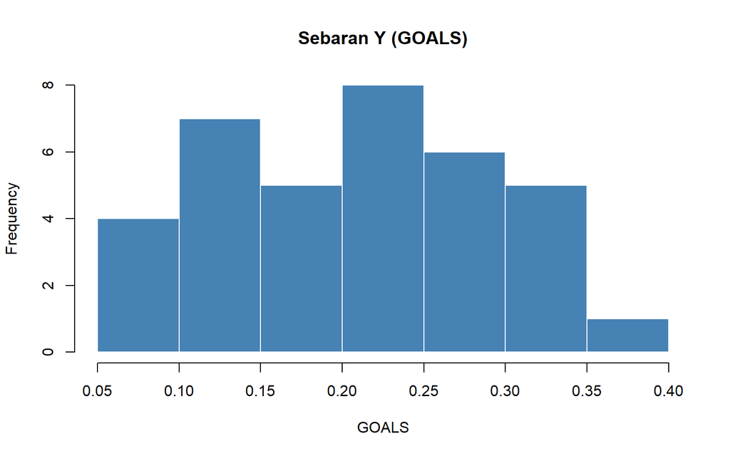

```r
hist(dt_plot$Y, main = "Sebaran Y (GOALS)",
     xlab = "GOALS", col = "steelblue", border = "white")
```

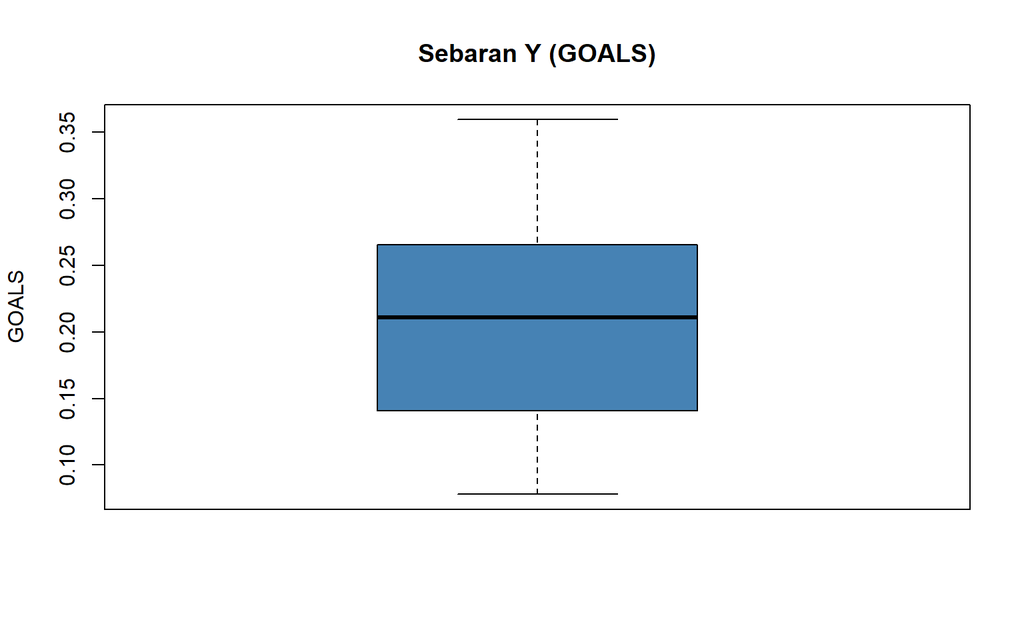

```r
boxplot(dt_plot$Y, main = "Sebaran Y (GOALS)",
        ylab = "GOALS", col = "steelblue")
```

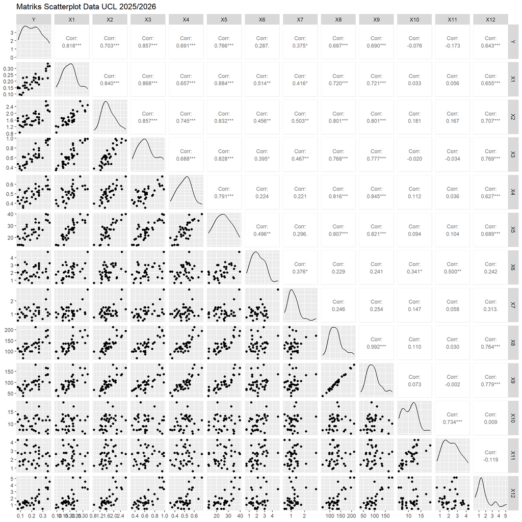

```r
ggpairs(dt_plot,
        upper = list(continuous = wrap("cor", size = 3)),
        title = "Matriks Scatterplot Data UCL 2025/2026")
```

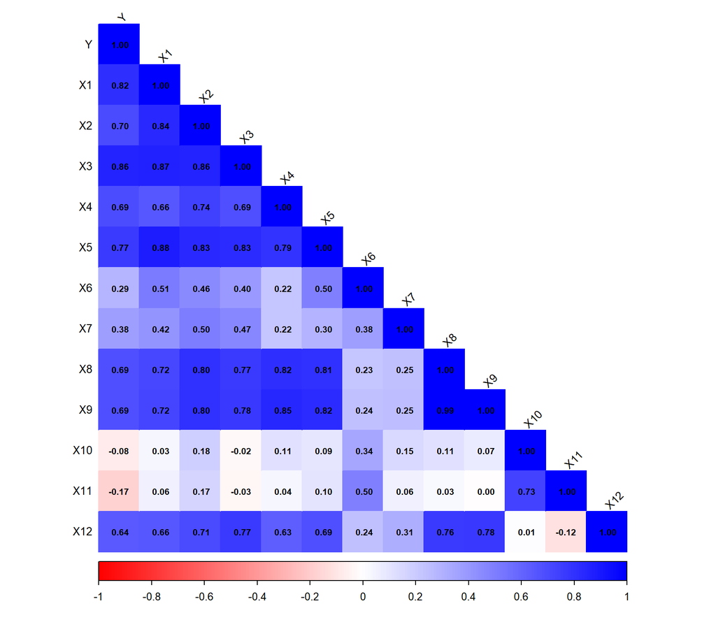

```r
cor_matrix <- cor(dt_plot, use = "complete.obs")

corrplot(cor_matrix, method = "color", type = "lower",
         col = colorRampPalette(c("red", "white", "blue"))(200),
         addCoef.col = "black", number.cex = 0.65,
         tl.col = "black", tl.srt = 45, tl.cex = 0.85)
```

Hasil matriks scatterplot dan korelasi menunjukkan bahwa peubah respon Y (GOALS) memiliki hubungan positif dengan hampir seluruh peubah penjelas. Hubungan terkuat dengan peubah respon ditunjukkan oleh X1 (XG) dan X3 (SOT) yang memiliki koefisien korelasi tinggi, mencerminkan bahwa kualitas tembakan dan tembakan tepat sasaran merupakan faktor utama yang memengaruhi jumlah gol yang dicetak tim di UCL 2025/2026.

Selain itu, terdapat beberapa korelasi yang cukup tinggi antar peubah penjelas, terutama antara X8 (PASS_F3RD_TOT) dan X9 (PASS_F3RD_SUC) yang menunjukkan hubungan sangat kuat karena keduanya mengukur umpan di zona yang sama. Demikian pula korelasi antara X2 (SHOTS) dan X3 (SOT) yang cukup tinggi. Hal ini mengindikasikan kemungkinan adanya multikolinearitas yang perlu diperiksa lebih lanjut.

# Pemodelan

## Tanpa Fungsi

Perhitungan nilai $\hat{\beta}$ secara matriks dapat dilakukan dengan rumus berikut.

$$\hat{\beta} = (X'X)^{-1}
X'y$$

```r
n <- nrow(dt)

x0 <- rep(1, n)

x <- data.frame(x0,
                dt$XG, dt$SHOTS, dt$SOT,
                dt$AVG_POSS, dt$TOU_IN_BOX, dt$HEADERS,
                dt$FAST_BREAKS, dt$PASS_F3RD_TOT, dt$PASS_F3RD_SUC,
                dt$CROSSES_TOT, dt$CROSS_SUC, dt$TROUGH_BALL)

x <- as.matrix(x)

y <- dt$GOALS
```

```r
beta_duga <- solve(t(x)%*%x)%*%t(x)%*%y
beta_duga
```

```
##                           [,1]
## x0               -0.2552656989
## dt.XG             0.4997448046
## dt.SHOTS         -0.0753565294
## dt.SOT            0.3017389676
## dt.AVG_POSS       0.4872135563
## dt.TOU_IN_BOX     0.0003068074
## dt.HEADERS        0.0044316501
## dt.FAST_BREAKS    0.0092791279
## dt.PASS_F3RD_TOT  0.0032444842
## dt.PASS_F3RD_SUC -0.0036617635
## dt.CROSSES_TOT    0.0017923096
## dt.CROSS_SUC     -0.0216134874
## dt.TROUGH_BALL   -0.0028756987
```

Hasil tersebut menjelaskan persamaan regresi berganda yang terbentuk dari seluruh peubah penjelas dalam memetakan karakteristik serangan tim terhadap rata-rata gol per pertandingan di UCL 2025/2026.

Selang kepercayaan dan pengujian signifikansi setiap parameter dapat dilakukan dengan menghitung keragaman tiap dugaan parameter. Secara umum, nilai ragam dugaan parameter $\hat{\beta}_j$ dapat dihitung melalui rumus berikut.

$$Var(\hat{\beta}_j) = \hat{\sigma}^2
C_{jj}$$

Dengan matriks $C$ adalah matriks $(X'X)^{-1}$

```r
c <- data.frame(solve(t(x)%*%x))
```

Unsur diagonal dari matriks $C$ dapat digunakan untuk menghitung nilai galat baku dari setiap dugaan parameter. Galat baku ini dapat digunakan untuk menghitung selang kepercayaan dari dugaan yang dihasilkan.

$$SE(\hat{\beta}_j) =
\sqrt{Var(\hat{\beta}_j)} = \sqrt{\sigma^2 C_{jj}} =
\hat{\sigma}\sqrt{c_{ii}}$$

Misal ingin dihitung selang kepercayaan dari dugaan parameter $\beta_1$ (koefisien XG), maka

```r
y_hat    <- x %*% beta_duga
residuals <- y - y_hat
n        <- nrow(x)
p        <- ncol(x)
KTG      <- sum(residuals^2) / (n - p)

c11 <- c[2,2]

(se.b1 <- sqrt(KTG*c11))
```

```
## [1] 0.3209061
```

```r
alfa <- 0.05

# Batas Bawah beta1
(bb.b1 <- beta_duga[2,1] - abs(qt(alfa/2, df=n-p))*se.b1)
```

```
##      dt.XG
## -0.1641001
```

```r
# Batas Atas beta1
(ba.b1 <- beta_duga[2,1] + abs(qt(alfa/2, df=n-p))*se.b1)
```

```
##   dt.XG
## 1.16359
```

Dengan demikian, kita dapat mengetahui selang kepercayaan untuk $\hat{\beta}_1$ (XG) pada taraf kepercayaan 95% sebagai berikut.

$$bb.b1 < \hat{\beta}_1 < ba.b1$$

Apabila selang kepercayaan tidak memuat nilai 0, maka $\hat{\beta}_1$ dinyatakan signifikan dalam menjelaskan rata-rata gol per pertandingan pada taraf nyata 5%. Sebaliknya, apabila selang kepercayaan memuat nilai 0, maka $\hat{\beta}_1$ tidak signifikan secara statistik.

## Dengan Fungsi

```r
model1 <- lm(formula = GOALS ~ ., data = dt)
summary(model1)
```

```
##
## Call:
## lm(formula = GOALS ~ ., data = dt)
##
## Residuals:
##       Min        1Q    Median        3Q       Max
## -0.079078 -0.020658  0.007826  0.021101  0.046288
##
## Coefficients:
##                 Estimate Std. Error t value Pr(>|t|)
## (Intercept)   -0.2552657  0.1029423  -2.480  0.02091 *
## XG             0.4997448  0.3209061   1.557  0.13306
## SHOTS         -0.0753565  0.0461170  -1.634  0.11587
## SOT            0.3017390  0.0998919   3.021  0.00609 **
## AVG_POSS       0.4872136  0.2101841   2.318  0.02969 *
## TOU_IN_BOX     0.0003068  0.0028188   0.109  0.91427
## HEADERS        0.0044317  0.0126302   0.351  0.72887
## FAST_BREAKS    0.0092791  0.0203989   0.455  0.65346
## PASS_F3RD_TOT  0.0032445  0.0020623   1.573  0.12933
## PASS_F3RD_SUC -0.0036618  0.0022358  -1.638  0.11508
## CROSSES_TOT    0.0017923  0.0037438   0.479  0.63665
## CROSS_SUC     -0.0216135  0.0126465  -1.709  0.10090
## TROUGH_BALL   -0.0028757  0.0099942  -0.288  0.77613
## ---
## Signif. codes:  0 '***' 0.001 '**' 0.01 '*' 0.05 '.' 0.1 ' ' 1
##
## Residual standard error: 0.04047 on 23 degrees of freedom
## Multiple R-squared:  0.8488, Adjusted R-squared:  0.7699
## F-statistic: 10.76 on 12 and 23 DF,  p-value: 9.054e-07
```

Dugaan parameter model secara matriks dan fungsi menghasilkan nilai yang sama, sehingga perhitungan matriks telah sesuai dengan hasil yang diperoleh menggunakan fungsi lm(). Berdasarkan hasil pengujian parsial, dapat diidentifikasi peubah-peubah yang berpengaruh signifikan terhadap rata-rata gol per pertandingan pada taraf signifikansi 5%. Secara simultan, model regresi yang terbentuk perlu dievaluasi berdasarkan nilai p-value uji F dan nilai Adjusted R-squared yang dihasilkan. Nilai Adjusted R-squared mencerminkan proporsi keragaman peubah respon GOALS yang dapat dijelaskan oleh peubah-peubah penjelas dalam model, sedangkan sisanya dijelaskan oleh faktor lain di luar model seperti strategi pelatih, kondisi fisik pemain, dan faktor nonteknis lainnya.

# Pemeriksaan Multikolinearitas

```r
vif(model1)
```

```
##            XG         SHOTS           SOT      AVG_POSS    TOU_IN_BOX
##      7.886996      7.240950      7.156669      5.276511      9.022235
##       HEADERS   FAST_BREAKS PASS_F3RD_TOT PASS_F3RD_SUC   CROSSES_TOT
##      2.691823      1.806939     94.544851    111.213224      2.646878
##     CROSS_SUC   TROUGH_BALL
##      3.185495      3.470387
```

Hasil uji VIF digunakan untuk memeriksa ada atau tidaknya masalah multikolinearitas antar peubah penjelas dalam model. Nilai VIF di bawah 5 mengindikasikan tidak adanya multikolinearitas yang serius, nilai antara 5 hingga 10 mengindikasikan multikolinearitas sedang, sedangkan nilai di atas 10 mengindikasikan multikolinearitas berat yang dapat memengaruhi kestabilan pendugaan parameter. Mengingat adanya beberapa peubah yang berkorelasi tinggi seperti X8 (PASS_F3RD_TOT) dan X9 (PASS_F3RD_SUC), kemungkinan besar beberapa peubah memiliki nilai VIF yang cukup tinggi. Berdasarkan hasil yang diperoleh, dapat ditentukan apakah perlu dilakukan penanganan multikolinearitas, seperti penghapusan salah satu peubah yang redundan atau penggunaan metode regresi alternatif.